# Carmel Valley Wildfire Smoke ‘Diurnicity’

Jonathan Callahan

2022-10-14

# Background

During the Soberanes Fire in California in 2016 [ref], the air quality monitoring station in Carmel Valley showed very high levels of particulate matter (PM2.5) from wildfire smoke which presented a serious public health risk to local residents, workers and firefighters. [ref] During the height of the smoke impacts in Carmel Valley, relatively calm weather lead to strong diurnal variations in air quality as land and sea breezes pushed smoke up and down the valley without the winds ever being strong enough to clear out the smoke. [ref]

The strong diurnal variation in air quality meant that, even during days with the worst daily average air quality, there were some hours when outside air was in the GOOD or MODERATE categories according to the Air Quality Index (AQI). [ref] This time-of-day variation in air quality can be supremely important information for those living in smoke-impacted areas as it allows them to plan when to hunker down inside and when to shop, check in on friends, or walk the dog.

This document presents a method for identifying days in an air quality time series that display strong diurnal cycles during periods of elevated smoke. We will create a *diurnicity* metric that can be applied elsewhere.

Having identified days of interest using the *diurnicity* metric, we then demonstrate how to find the hour of the day at which a maximum value of PM 2.5 occurred so that we can advise people when to stay indoors and when it is safe to breathe outdoor air.

# Method

We will use Carmel Valley monitoring data from 2016 to develop an algorithm for detecting *diurnicity*.

We begin by downloading annual air quality data for 2016 and displaying an interactive map of California monitors during the first week of August, 2016. This map displays monitors colored by the maximum hourly value experienced during that time period.

The Carmel Valley monitor is located below San Francisco and is colored as HAZARDOUS.

[interactive chart not shown]

## Soberanes Fire

The Soberanes fire began on July 22, 2016 and was not fully extinguished until October 12, 2016. The bulk of the smoke impacts in the Carmel Valley occurred in the first three weeks of the fire. [ref]

The following plot shows the diurnal cycle of PM 2.5 measurement with individual measurements plotted by time-of-day along with averages of all measurements for each time-of-day. A strong diurnal signal is present with UNHEALTHY conditions (red on the AQI scale) many mornings and GOOD conditions most evenings.

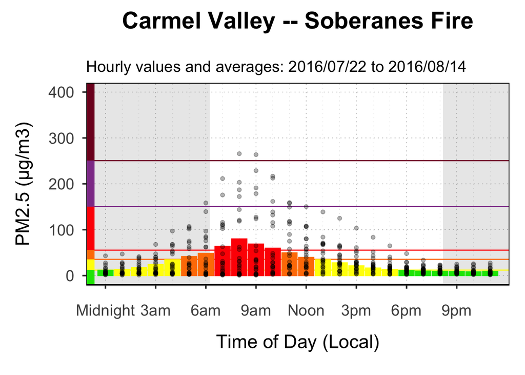

## *“Diurnicity”*

A simple metric to capture this diurnal signal during periods of strong health impacts can be calculated by first converting PM 2.5 values to their equivalent AQI Level (GOOD = 1, MODERATE = 2, *etc.*) and then using rolling versions of *max*, *mean* and *min* functions to calculate 24-hr averages.

In R pseudocode, this would look like:

```
min <- roll_min(hourly_AQI_level)
mean <- roll_mean(hourly_AQI_level)
max <- roll_max(hourly_AQI_level)

diurnicity <- 10 * mean * (max - min)
```

Each of `min`, `mean` and `max` will vary between AQI levels 1 and 6. The factor of 10 is included so that *diurnicity* will be visible when plotted on top of monitoring data.

During the worst days of the Soberanes fire, daily averages were at the UNHEALTHY level and the *diurnicity* would evalute to:

```
10 * 4 * (6 - 2) = 160
```

This new *diurnicity* metric can be used to identify time periods of interest as seen in the following plots. Day-night shading is used to more easily identify the diurnal cycle.

A dashed line at `diurnicity = 20` suggests a threshold above which days can be considered to have a both PM 2.5 levels of concern and a strong diurnal cycle.

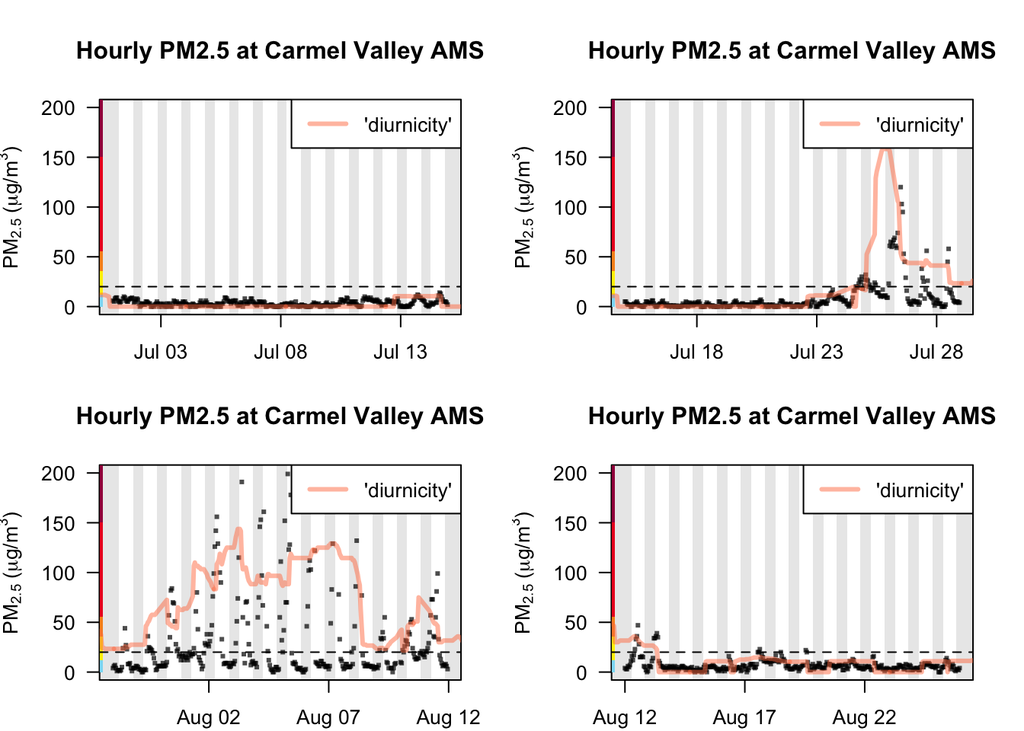

## Hour of PM 2.5 Max during strong *diurnicity*

Our overall goal is to identify those days with strong *diurnicity* and to determine when the maximum PM 2.5 value occurred on those days.

We can identify “diurnal days” using the threshold suggested above. We can then calculate a rolling 24-hour maximum to identify the local time-of-day. Combining them, we can identify and then tabulate the time-of-day for all days with a strong diurnal signal.

In R pseudocode:

```
diurnal_day_mask <- diurnicity > 20
24_hour_mask <- time == roll_max(time)
```

The following plots show how the masks identify the times we are interested in:

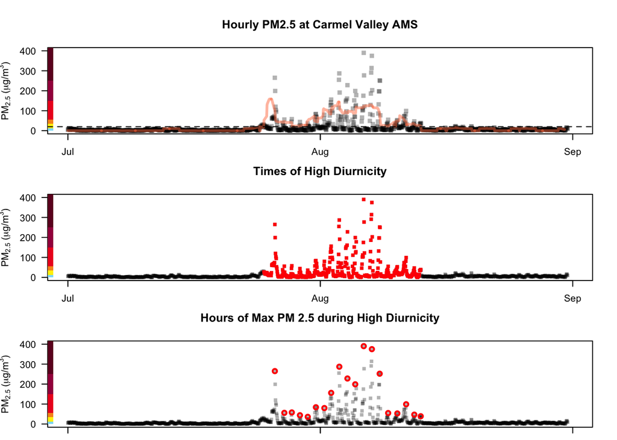

## Time-of-day

The times identified above can now be tabulated to see when the strong diurnal cycle typically peaks. In fact, we already know from the very first plot that the peak occurs in the morning. But the algorithm we have just developed is very fast (it uses C++ rollling functions) and could be applied to all monitors over multiple years to gain a statistical understanding of different categories of *diurnicity*.

For Carmel Valley during the Soberanes fire, the hours of maximum PM2.5 during *diurnicity* are seen below:

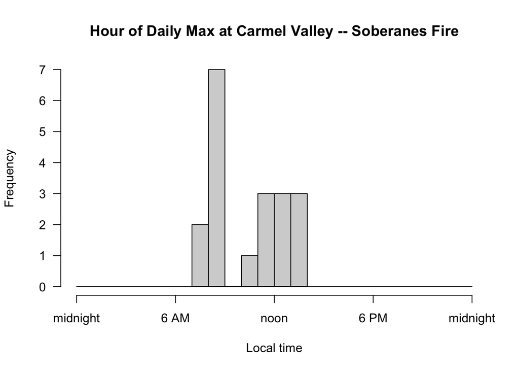

# Next Steps

## Identify all periods with *diurnicity*

With this new metric in hand, it would be straightforward to run through 10 years worth of data for all AirNow monitoring stations and identify periods of strong *diurnicity*.

## Determine phase of *diurnicity*

As *diurnicity* implies an almost sinusoidal signal, we should be able to use the time of the daily maximum to identify a “phase” fore each trace – *i.e.* the rough time of day of the peak. I am imagining we could divide the day up into 3-hour chunks for this.

## Cluster time series based on strength and phase of *diurnicity*

If we find enough periods with strong *diurnicity*, we could use clustering or other machine learning techniques to potentially categorize different types of locations, weather patterns or fire behavior.